# uwa6xv_M03_HW

Alanna Hazlett

2024-02-14

# Problem 1

We will use the dataset “copier.txt” for this question. The Tri-City Office Equipment Corporation sells an imported copier on a franchise basis and performs preventive maintenance and repair service on this copier. The data have been collected from 45 recent calls on users to perform routine preventive maintenance service; for each call, Serviced is the number of copiers serviced and Minutes is the total number of minutes spent by the service person.  
**(a)**  
The predictor variable is “Serviced”, the number of copiers serviced. The response variable is “Minutes”, the total number of minutes spent servicing the copiers.  
**(b)**  
Produce a scatterplot of the two variables. How would you describe the relation- ship between the number of copiers serviced and the time spent by the service person?

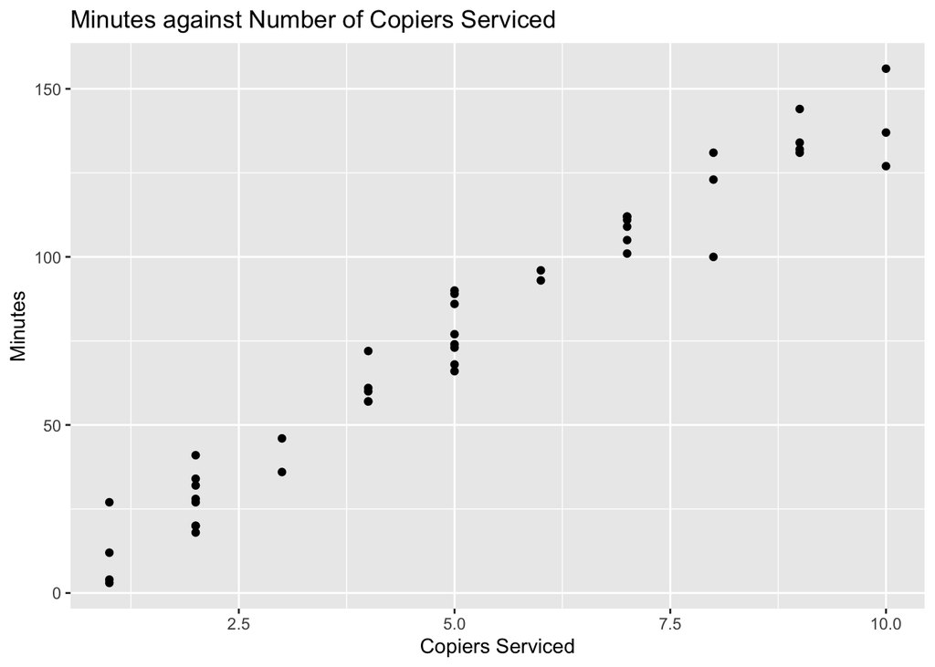

```r
ggplot(copier,aes(x=Serviced,y=Minutes))+
  geom_point()+
  labs(x="Copiers Serviced",y="Minutes",title="Minutes against Number of Copiers Serviced")
```

The relationship between number of copiers serviced and minutes spent servicing the copiers appears to be a positive linear relationship. As the number of copiers increase, so does the number of minutes spent servicing them.  
**(c)**  
What is the correlation between the total time spent by the service person and the number of copiers serviced? Interpret this correlation contextually.

```r
cor(copier$Serviced,copier$Minutes)
```

```
## [1] 0.978517
```

The correlation is a positive value, which indicates that as Serviced increases, so does Minutes. It is a strong association, in that the value is near 1, meaning that the number of copiers serviced highly affects the number of minutes servicing the copiers.  
**(d)**  
Can the correlation found in part 1c be interpreted reliably? Briefly explain.  
The correlation of 0.97 can be interpreted reliably, because there does not appear to be any curves or distinct outliers in our scatterplot that would alter our correlation value.  
**(e)**  
Use the lm() function to fit a linear regression for the two variables. Where are the values of beta1, beta0, R2, and sigma2 for this linear regression?

```r
result<-lm(Minutes~Serviced,data=copier)
summary(result)
```

```
##
## Call:
## lm(formula = Minutes ~ Serviced, data = copier)
##
## Residuals:
##      Min       1Q   Median       3Q      Max
## -22.7723  -3.7371   0.3334   6.3334  15.4039
##
## Coefficients:
##             Estimate Std. Error t value Pr(>|t|)
## (Intercept)  -0.5802     2.8039  -0.207    0.837
## Serviced     15.0352     0.4831  31.123   <2e-16 ***
## ---
## Signif. codes:  0 '***' 0.001 '**' 0.01 '*' 0.05 '.' 0.1 ' ' 1
##
## Residual standard error: 8.914 on 43 degrees of freedom
## Multiple R-squared:  0.9575, Adjusted R-squared:  0.9565
## F-statistic: 968.7 on 1 and 43 DF,  p-value: < 2.2e-16
```

```r
anova.tab<-anova(result)
anova.tab
```

```
## Analysis of Variance Table
##
## Response: Minutes
##           Df Sum Sq Mean Sq F value    Pr(>F)
## Serviced   1  76960   76960  968.66 < 2.2e-16 ***
## Residuals 43   3416      79
## ---
## Signif. codes:  0 '***' 0.001 '**' 0.01 '*' 0.05 '.' 0.1 ' ' 1
```

The F statistic is:
$$F=\frac{MS_{R}}{MS_{res}}=968.66$$
Our hypotheses are:
$$H_{0}: \hat\beta_{1} = 0$$
$$H_{a}: \hat\beta_{1} \neq 0$$

```r
qf(1-0.05, 1, 45-2)
```

```
## [1] 4.067047
```

Our F statistic of 968.66 is larger than our critical value of 4.06 (alternatively our p-value of 2.2X10^-16 is smaller than 0.05), so we reject our null hypothesis of
$$\hat\beta_{1}=0$$
our data supports the alternative hypothesis of the slope being different from 0, which indicates a linear association between our variables of Serviced and Minutes for the copiers.